# 기말고사 예상문제 201822037 통계학과 한민주

## imports

```python
import numpy as np
import matplotlib.pyplot as plt
import tensorflow as tf
import tensorflow.experimental.numpy as tnp
```

```python
tnp.experimental_enable_numpy_behavior()
```

```python
%load_ext tensorboard
```

```python
import graphviz
def gv(s): return graphviz.Source('digraph G{ rankdir="LR"'+ s + ';}')
```

## 1. Fashion_mnist, DNN (30점)

`(1)` `tf.keras.datasets.fashion_mnist.load_data()`을 이용하여 fashion_mnist 자료를 불러온 뒤 아래의 네트워크를 이용하여 적합하라.

- 평가지표로 accuracy를 이용할 것
- epoch은 10으로 설정할 것
- optimizer는 adam을 이용할 것

```python
#collapse
gv('''
splines=line
subgraph cluster_1{
    style=filled;
    color=lightgrey;
    "x1"
    "x2"
    ".."
    "x784"
    label = "Layer 0"
}
subgraph cluster_2{
    style=filled;
    color=lightgrey;
    "x1" -> "node1"
    "x2" -> "node1"
    ".." -> "node1"
    "x784" -> "node1"

    "x1" -> "node2"
    "x2" -> "node2"
    ".." -> "node2"
    "x784" -> "node2"

    "x1" -> "..."
    "x2" -> "..."
    ".." -> "..."
    "x784" -> "..."

    "x1" -> "node20"
    "x2" -> "node20"
    ".." -> "node20"
    "x784" -> "node20"


    label = "Layer 1: relu"
}
subgraph cluster_3{
    style=filled;
    color=lightgrey;
    "node1" -> "node1 "
    "node2" -> "node1 "
    "..." -> "node1 "
    "node20" -> "node1 "

    "node1" -> "node2 "
    "node2" -> "node2 "
    "..." -> "node2 "
    "node20" -> "node2 "

    "node1" -> "... "
    "node2" -> "... "
    "..." -> "... "
    "node20" -> "... "

    "node1" -> "node30 "
    "node2" -> "node30 "
    "..." -> "node30 "
    "node20" -> "node30 "


    label = "Layer 2: relu"
}
subgraph cluster_4{
    style=filled;
    color=lightgrey;

    "node1 " -> "y10"
    "node2 " -> "y10"
    "... " -> "y10"
    "node30 " -> "y10"

    "node1 " -> "y1"
    "node2 " -> "y1"
    "... " -> "y1"
    "node30 " -> "y1"

    "node1 " -> "."
    "node2 " -> "."
    "... " -> "."
    "node30 " -> "."

    label = "Layer 3: softmax"
}
''')
```

[figure not shown]

```python
(x_train , y_train) , (x_test , y_test) = tf.keras.datasets.fashion_mnist.load_data()
```

```python
x_train.shape , y_train.shape , x_test.shape, y_test.shape
```

```
((60000, 28, 28), (60000,), (10000, 28, 28), (10000,))
```

```python
## 데이터 정리 , one-hot인코딩
X = tf.constant(x_train.reshape(-1, 28*28) , dtype = tf.float64)
y = tf.keras.utils.to_categorical(y_train)
XX = tf.constant(x_test.reshape(-1, 28*28) , dtype = tf.float64)
yy = tf.keras.utils.to_categorical(y_test)
## 네트워크 설계
tf.random.set_seed(201822037) ## 랜덤값 고정
net = tf.keras.Sequential()
net.add(tf.keras.layers.Dense(20 , activation = 'relu'))
net.add(tf.keras.layers.Dense(30 , activation = 'relu'))
net.add(tf.keras.layers.Dense(10 , activation = 'softmax'))
net.compile(loss = tf.keras.losses.categorical_crossentropy, optimizer = 'adam', metrics = ['accuracy'])
net.fit(X,y ,epochs = 10 , batch_size =100 ) ## mini batch
```

```
<keras.callbacks.History at 0x7f867a862810>
```

`(2)` (1)에서 적합된 네트워크를 이용하여 test data의 accuracy를 구하라.

```python
net.evaluate(XX,yy)[1]  ## test data의 accuracy만 출력
```

```
0.6414999961853027
```

`(3)` train set에서 20%의 자료를 validation 으로 분리하여 50에폭동안 학습하라. 텐서보드를 이용하여 train accuracy와 validation accuracy를 시각화 하고 결과를 해석하라. 오버피팅이라고 볼 수 있는가?

```python
## 네트워크 설계
tf.random.set_seed(201822037) ## 랜덤값 고정
net2 = tf.keras.Sequential()
net2.add(tf.keras.layers.Dense(20 , activation = 'relu'))
net2.add(tf.keras.layers.Dense(30 , activation = 'relu'))
net2.add(tf.keras.layers.Dense(10 , activation = 'softmax'))
net2.compile(loss = tf.keras.losses.categorical_crossentropy, optimizer = 'adam', metrics = ['accuracy'])
cb1 = tf.keras.callbacks.TensorBoard() ## tensorboard
net2.fit(X,y ,epochs = 50 , batch_size =100 , validation_split = 0.2 , callbacks = cb1) ## mini batch
```

```
<keras.callbacks.History at 0x7f867a597d50>
```

```python
%tensorboard --logdir logs
#!kill 1580
# !rm -rf logs
```

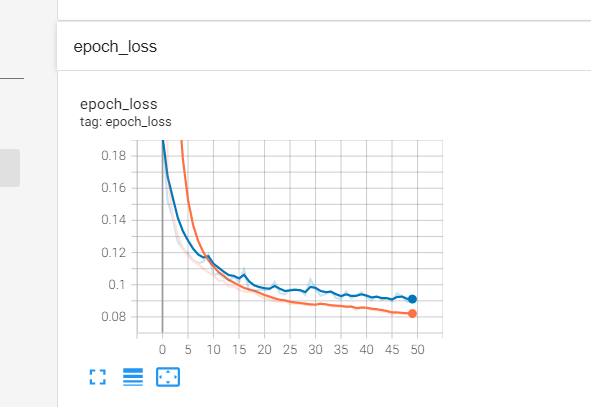

training data의 loss가 감소함에 따라 validation data의 loss도 감소하고 있으므로 오버피팅이 아니다. (오버피팅이면 training data의 loss가 감소함에도 validation data의 loss가 증가한다)

`(4)` (3)에서 적합된 네트워크를 이용하여 test data의 accuracy를 구하라. (2)의 결과와 비교하라.

```python
net.evaluate(XX,yy)[1] , net2.evaluate(XX,yy)[1] ## (2)네트워크의 test data의 accuracy보다 커졌으므로 (3)의 네트워크가 더 좋다.
```

```
(0.6414999961853027, 0.8190000057220459)
```

`(5)` 조기종료기능을 이용하여 (3)의 네트워크를 다시 학습하라. 학습결과를 텐서보드를 이용하여 시각화 하라.

- patience=3 으로 설정할 것

```python
!rm -rf logs
## 네트워크 설계
tf.random.set_seed(201822037) ## 랜덤값 고정
net2 = tf.keras.Sequential()
net2.add(tf.keras.layers.Dense(20 , activation = 'relu'))
net2.add(tf.keras.layers.Dense(30 , activation = 'relu'))
net2.add(tf.keras.layers.Dense(10 , activation = 'softmax'))
net2.compile(loss = tf.keras.losses.categorical_crossentropy, optimizer = 'adam', metrics = ['accuracy'])
cb1 = tf.keras.callbacks.TensorBoard() ## tensorboard
cb2 = tf.keras.callbacks.EarlyStopping(patience=3) ## 조기종료
net2.fit(X,y ,epochs = 50 , batch_size =100 , validation_split = 0.2 , callbacks = [cb1,cb2])
```

```
<keras.callbacks.History at 0x7f867a3b7210>
```

```python
# !kill 2340
%tensorboard --logdir logs
```

```
Reusing TensorBoard on port 6006 (pid 2578), started 0:00:42 ago. (Use '!kill 2578' to kill it.)
```

## 2. Fashion_mnist, CNN (30점)

`(1)` `tf.keras.datasets.fashion_mnist.load_data()`을 이용하여 fashion_mnist 자료를 불러온 뒤 아래의 네트워크를 이용하여 적합하라.

- 이때 n1=6, n2=16, n3=120 으로 설정한다, 드랍아웃비율은 20%로 설정한다.
- `net.summary()`를 출력하여 설계결과를 확인하라.

[figure not shown]

```python
(x_train , y_train) , (x_test , y_test) = tf.keras.datasets.fashion_mnist.load_data()
```

```python
x_train.shape , y_train.shape , x_test.shape , y_test.shape
```

```
((60000, 28, 28), (60000,), (10000, 28, 28), (10000,))
```

```python
## 데이터 정리 , one-hot인코딩
X = tf.constant(x_train.reshape(-1, 28, 28, 1) , dtype = tf.float64)
y = tf.keras.utils.to_categorical(y_train)
XX = tf.constant(x_test.reshape(-1, 28, 28,1) , dtype = tf.float64)
yy = tf.keras.utils.to_categorical(y_test)
```

```python
net = tf.keras.Sequential()
net.add(tf.keras.layers.Conv2D(6,(5,5)))
net.add( tf.keras.layers.MaxPooling2D())
net.add(tf.keras.layers.Conv2D(16, (5,5)))
net.add(tf.keras.layers.MaxPooling2D())
net.add(tf.keras.layers.Flatten())
net.add(tf.keras.layers.Dense(120 , activation = 'relu'))
net.add(tf.keras.layers.Dropout(0.2))
net.add(tf.keras.layers.Dense(10 , activation= 'softmax'))
net.compile(loss = tf.keras.losses.categorical_crossentropy, optimizer = 'adam', metrics = ['accuracy'])
net.fit(X,y , epochs=10 , batch_size= 100 )
```

```
<keras.callbacks.History at 0x7f85afde06d0>
```

```python
net.evaluate(XX,yy)
```

```
[0.35848456621170044, 0.8727999925613403]
```

```python
net.summary()
```

```
Model: "sequential_80"
_________________________________________________________________
 Layer (type)                Output Shape              Param #
=================================================================
 conv2d_92 (Conv2D)          (None, 24, 24, 6)         156

 max_pooling2d_86 (MaxPoolin  (None, 12, 12, 6)        0
 g2D)

 conv2d_93 (Conv2D)          (None, 8, 8, 16)          2416

 max_pooling2d_87 (MaxPoolin  (None, 4, 4, 16)         0
 g2D)

 flatten_43 (Flatten)        (None, 256)               0

 dense_197 (Dense)           (None, 120)               30840

 dropout_43 (Dropout)        (None, 120)               0

 dense_198 (Dense)           (None, 10)                1210

=================================================================
Total params: 34,622
Trainable params: 34,622
Non-trainable params: 0
_________________________________________________________________
```

`(2)` n1=(6,64,128), n2=(16,256)에 대하여 test set의 loss가 최소화되는 조합을 찾아라. 결과를 텐서보드로 시각화하는 코드를 작성하라.

- epoc은 3회로 한정한다.
- validation_split은 0.2로 설정한다.

```python
from tensorboard.plugins.hparams import api as hp
```

```python
!rm -rf logs
for n1 in [6,64 ,128]:
    for n2 in [16 , 256]:
          logdir = 'logs/hpguebin_{}_{}'.format(n1,n2)
          with tf.summary.create_file_writer(logdir).as_default():
              tf.random.set_seed(201822037)
              net = tf.keras.Sequential()
              net.add(tf.keras.layers.Conv2D(n1,(5,5)))
              net.add( tf.keras.layers.MaxPooling2D())
              net.add(tf.keras.layers.Conv2D(n2, (5,5)))
              net.add(tf.keras.layers.MaxPooling2D())
              net.add(tf.keras.layers.Flatten())
              net.add(tf.keras.layers.Dense(120 , activation = 'relu'))
              net.add(tf.keras.layers.Dropout(0.2))
              net.add(tf.keras.layers.Dense(10, activation = 'softmax'))
              net.compile(loss=tf.losses.categorical_crossentropy, optimizer = 'adam', metrics = ['accuracy'])
              cb3 = hp.KerasCallback(logdir, {'n1':n1, 'n2':n2})
              net.fit(X,y , epochs=3  , validation_split = 0.2  , callbacks = cb3 )
              _rslt=net.evaluate(XX,yy)
              tf.summary.scalar('loss(테스트셋)', _rslt[0], step=1)
```

```python
%tensorboard --logdir logs ## n1 = 6 , n2 = 256일 때, test loss가 최소이다.
#!kill 2578
```

## 3. CIFAR10 (30점)

`tf.keras.datasets.cifar10.load_data()`을 이용하여 CIFAR10을 불러온 뒤 적당한 네트워크를 사용하여 적합하라.

- 결과를 텐서보드로 시각화할 필요는 없다.
- 자유롭게 모형을 설계하여 적합하라.
- test set의 accuracy가 70%이상인 경우만 정답으로 인정한다.

```python
tf.keras.datasets.cifar10.load_data??
```

- y 값은 0~9까지 중 하나
- x의 채널 수 3
- (x_train, y_train), (x_test, y_test) 가 return 된다

```python
(x_train, y_train), (x_test, y_test) = tf.keras.datasets.cifar10.load_data()
```

```
Downloading data from https://www.cs.toronto.edu/~kriz/cifar-10-python.tar.gz
```

```python
x_train.shape , y_train.shape , x_test.shape , y_test.shape
```

```
((50000, 32, 32, 3), (50000, 1), (10000, 32, 32, 3), (10000, 1))
```

```
[6]
```

```
(<matplotlib.image.AxesImage at 0x7f867a788f50>, None)
```

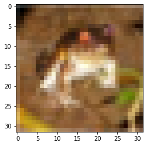

```python
plt.imshow(x_train[0]) , print(y_train[0]) #6 : frog
```

```
[9]
```

```
(<matplotlib.image.AxesImage at 0x7f867d5d4450>, None)
```

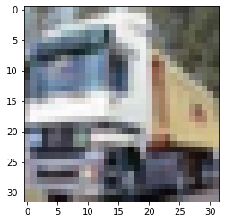

```python
plt.imshow(x_train[1]) , print(y_train[1]) #9  : truck
```

```python
## 데이터 정리 , one-hot인코딩
X = tf.constant(x_train.reshape(-1, 32, 32, 3) , dtype = tf.float64)
y = tf.keras.utils.to_categorical(y_train)
XX = tf.constant(x_test.reshape(-1, 32, 32,3) , dtype = tf.float64)
yy = tf.keras.utils.to_categorical(y_test)
## 네트워크 설계
net = tf.keras.Sequential()
net.add(tf.keras.layers.Conv2D(10,(4,4)))
net.add( tf.keras.layers.MaxPooling2D())
net.add(tf.keras.layers.Flatten())
net.add(tf.keras.layers.Dense(30 , activation = 'relu'))
net.add(tf.keras.layers.Dropout(0.2))
net.add(tf.keras.layers.Dense(10 , activation= 'softmax'))
net.compile(loss = tf.keras.losses.categorical_crossentropy, optimizer = 'adam', metrics = ['accuracy'])
net.fit(X,y , epochs=10 , batch_size= 100 )
```

[output not shown]

```python
net.evaluate(XX,yy)
```

```
[2.3025903701782227, 0.10000000149011612]
```

## 4. 다음을 읽고 물음에 답하라. (10점)

(1) (128,128,3)의 shape을 가진 텐서가 `tf.keras.layers.Conv2D(5,(2,2))`으로 만들어진 커널을 통과할시 나오는 shape은?

```python
XXX = tnp.arange(1*128*128*3 , dtype = tf.float64).reshape(1,128,128,3)
conv2d = tf.keras.layers.Conv2D(5,(2,2))
conv2d(XXX).shape
```

```
TensorShape([1, 127, 127, 5])
```

(1, 127,127 ,5) 이다. (관측치 수 , 픽셀 , 픽셀, 채널 수)

(2) (24,24,16)의 shape을 가진 텐서가 `tf.keras.layers.Flatten()`을 통과할때 나오는 텐서의 shape은?

```python
XXX = tnp.arange(1*24*24*16 , dtype = tf.float64).reshape(1,24,24,16)
flatten = tf.keras.layers.Flatten()
flatten(XXX).shape
```

```
TensorShape([1, 9216])
```

```python
24*24*16
```

```
9216
```

(1,9216)이다.